# Hw2

**5.Compare and contrast geom_violin() with a facetted geom_histogram(), or a coloured geom_freqpoly(). What are the pros and cons of each method?**

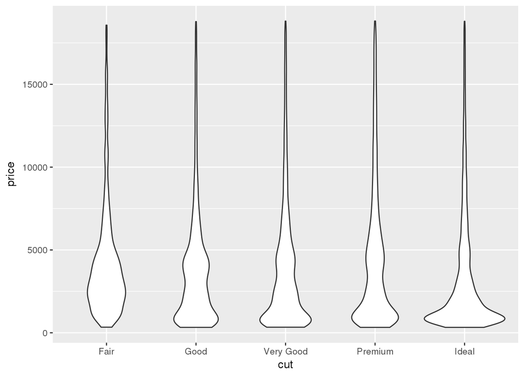

```r
diamonds %>%
  ggplot(aes(cut, price)) +
  geom_violin()
```

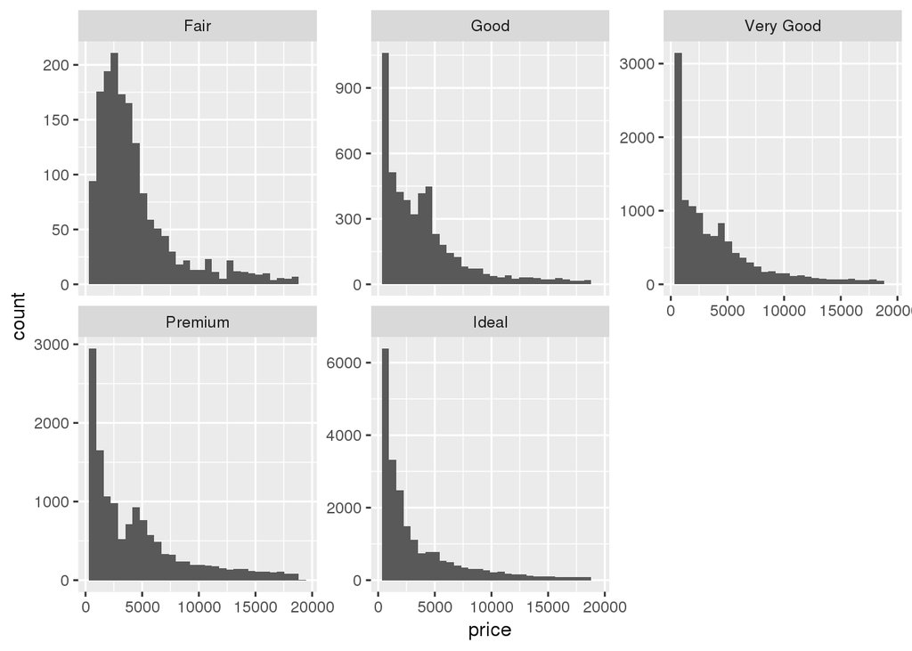

```r
diamonds %>%
  ggplot(aes(price)) +
  geom_histogram() +
  facet_wrap(~ cut, scale = "free_y")
```

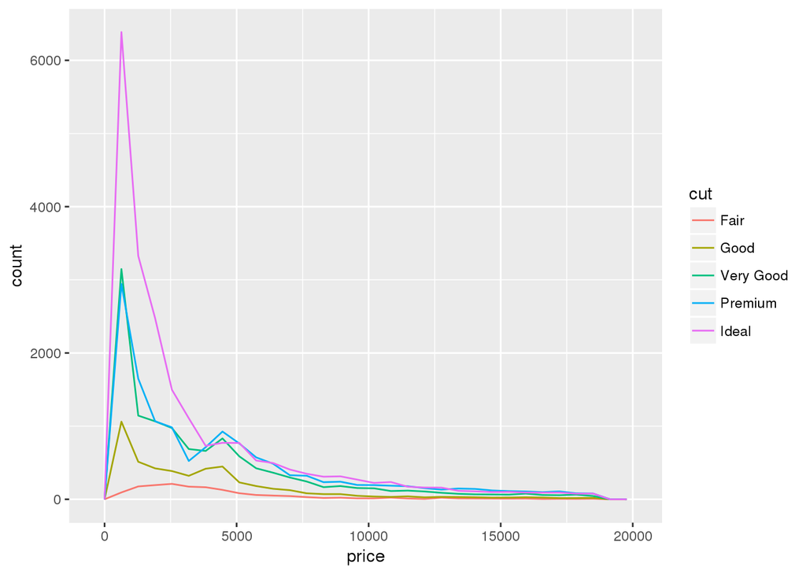

```r
diamonds %>%
  ggplot(aes(price)) +
  geom_freqpoly(aes(colour = cut))
```

The violin plot gives a side by side outline of the general shape of the distribution for each cut. We can see that the data for price is highly right skewed. The facetted histogram gives separate side by side histograms of each cut and the frequency polygon gives counts of each type of cut that is worth a certain price. The violin plot gives a picture of the distribution while the facetted histogram allows the user to take a closer look at the data and exact shape of the distribution. The frequency polygon is a line graph that draws the counts of each cut worth certain prices.

**The following are pros for each plot:**

- The violin plot is useful for comparing the shapes of distributions across all cuts.
- The facetted histogram allows one to easily see that price is extremely right skewed
- The frequency polygon allows one to see the frequency of prices for each cut. For example, the largest peak shows that the most common diamond in this dataset is an ideal cut for about $1,000.

**The following are cons for each plot:**

- The violin plot does not tell us about the exact frequency of cuts of diamonds worth a certain price. We can only guess and subjectively compare across the categories.
- For the facetted histogram, if there were more categories for cuts (i.e. more than 10 categories), it would be difficult to compare the histograms (which tell us about the shape of the distribution of the data) side by side. It would be more useful to overlay the histograms.
- For the frequency polygon, it is difficult to distinguish the overlapping lines towards the upper half of price. It is not useful for determining the exact shape of the distribution of the data.

**6. If you have a small dataset, it’s sometimes useful to use geom_jitter() to see the relationship between a continuous and categorical variable. The ggbeeswarm package provides a number of methods similar to geom_jitter(). List them and briefly describe what each one does.**

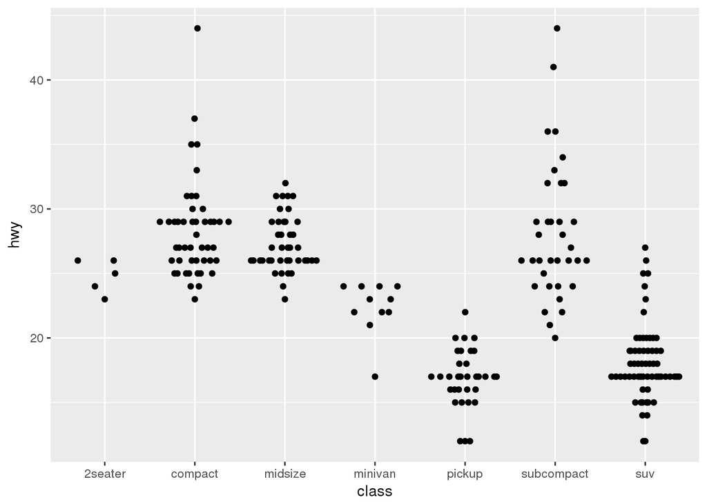

```r
library("ggbeeswarm")

#Use a smaller dataset, MPG, and compare hwy (highway mpg) vs. car class
ggplot(data = mpg) +
  geom_quasirandom(aes(x = class, y = hwy))
```

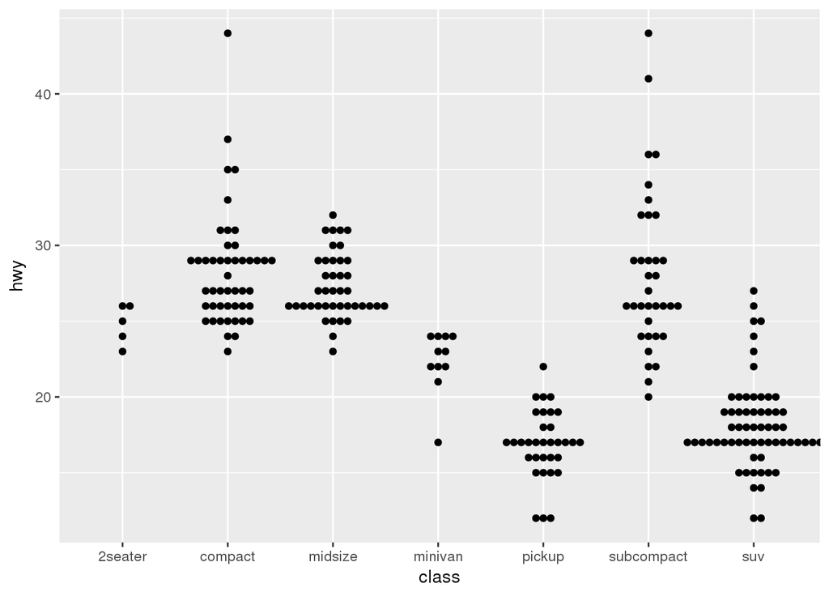

```r
ggplot(data = mpg) +
  geom_beeswarm(aes(x = class, y = hwy))
```

Both geom_quasirandom and geom_beeswarm use jittering to reduce overplotting by plotting the points next to each other rather than overlapping each other. The shapes of these plots are similar to a violin plot. They give insight to the shape of the distribution of the data. The difference between the two is that they have differenet algorithims when “offsetting” points. Specifically, geom_quasirandom “uses a van der Corput sequence or Tukey texturing”geom_beeswarm “uses the beeswarm library to do point-size based offset. (Source: https://github.com/eclarke/ggbeeswarm)

# 7.5.2.1 Exercises

**1. How could you rescale the count dataset above to more clearly show the distribution of cut within colour, or colour within cut?**

The original plot given is:

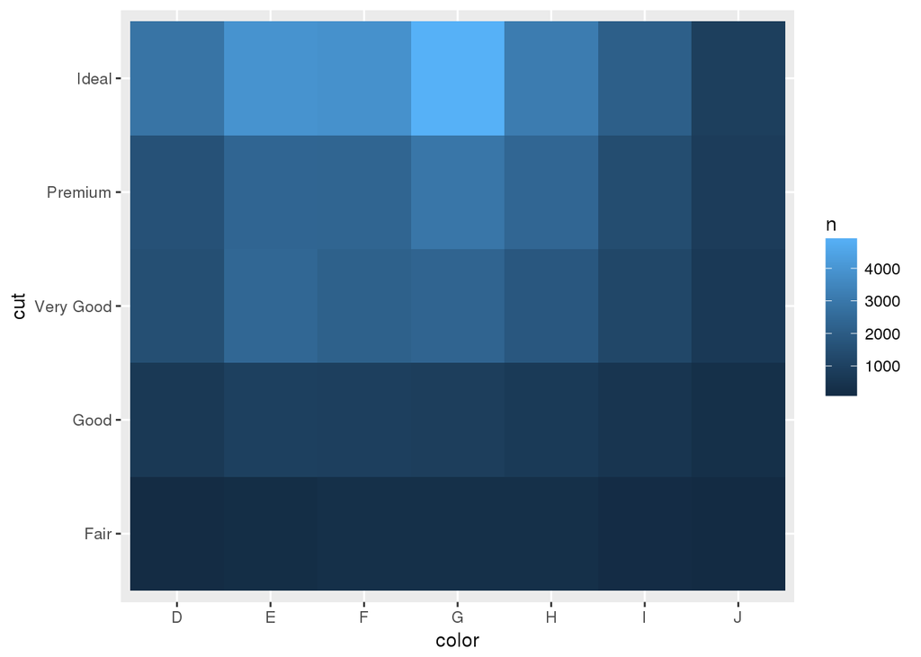

```r
diamonds %>%
  count(color, cut) %>%
  ggplot(mapping = aes(x = color, y = cut)) +
    geom_tile(mapping = aes(fill = n))
```

Instead of looking at counts, the plot can be improved by calculating percentages/proportions of diamonds that are a certain color and cut.

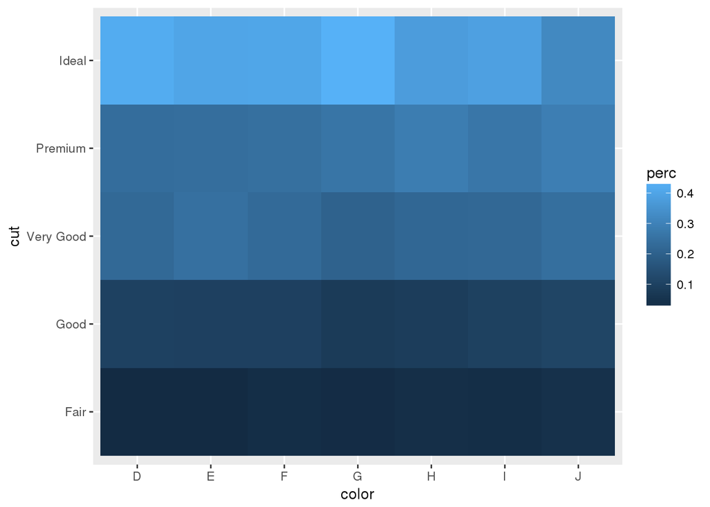

```r
diamonds %>%
  count(color, cut) %>%
  group_by(color) %>%
  mutate(perc = n / sum(n)) %>%
  ggplot(aes(color, cut, fill = perc)) +
  geom_tile()
```